# R_TUTORIAL_DESCRIPTIVES

# Goals for this tutorial:

1. Learn basics of plotting descriptives in R
2. Learn tools to generate descriptive statistics in R

# Let’s explore a sample dataset!

We will use mtcars, available in base R. The data was extracted from the 1974 Motor Trend US magazine, and comprises fuel consumption and 10 aspects of automobile design and performance for 32 automobiles (1973–74 models). For more information, click here: https://stat.ethz.ch/R-manual/R-devel/library/datasets/html/mtcars.html

Frst we will check the data to make sure (a) it’s a dataframe (b) what the column names are (c) how many rows and columns (d) snapshot of the data itself

```r
class(mtcars) # it's a data frame!
```

```
## [1] "data.frame"
```

```r
names(mtcars) # lists out column names (Variable names)
```

```
##  [1] "mpg"  "cyl"  "disp" "hp"   "drat" "wt"   "qsec" "vs"   "am"   "gear"
## [11] "carb"
```

```r
nrow(mtcars) # number of rows
```

```
## [1] 32
```

```r
ncol(mtcars) # number of columns
```

```
## [1] 11
```

```r
str(mtcars) # get a snaphot of the data inside the dataframe
```

```
## 'data.frame':    32 obs. of  11 variables:
##  $ mpg : num  21 21 22.8 21.4 18.7 18.1 14.3 24.4 22.8 19.2 ...
##  $ cyl : num  6 6 4 6 8 6 8 4 4 6 ...
##  $ disp: num  160 160 108 258 360 ...
##  $ hp  : num  110 110 93 110 175 105 245 62 95 123 ...
##  $ drat: num  3.9 3.9 3.85 3.08 3.15 2.76 3.21 3.69 3.92 3.92 ...
##  $ wt  : num  2.62 2.88 2.32 3.21 3.44 ...
##  $ qsec: num  16.5 17 18.6 19.4 17 ...
##  $ vs  : num  0 0 1 1 0 1 0 1 1 1 ...
##  $ am  : num  1 1 1 0 0 0 0 0 0 0 ...
##  $ gear: num  4 4 4 3 3 3 3 4 4 4 ...
##  $ carb: num  4 4 1 1 2 1 4 2 2 4 ...
```

# 1. skew/ normality of variables

Pplot histogram of a continuous variable, miles per gallon:

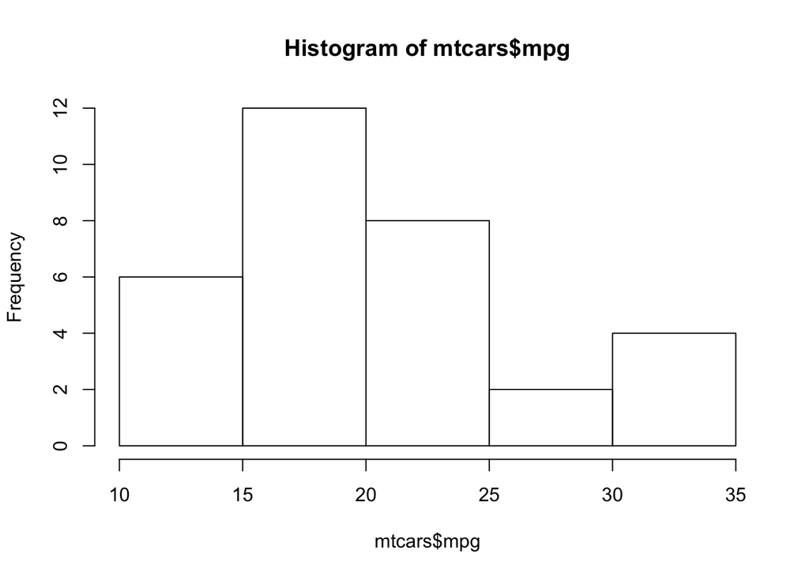

```r
hist(mtcars$mpg)
```

Next, make your histogram prettier with some extra arguments. base R graphics have many more options, these are just a few to get you started.

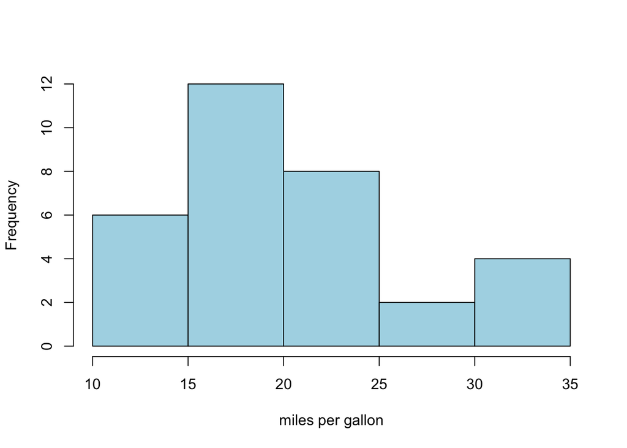

```r
hist(mtcars$mpg, col= "light blue", main = "", ylab = "Frequency", xlab = "miles per gallon")
```

Quantative assessments of skew:

```r
#skewness
skewness(mtcars$mpg)# positive skew means the Mean > median.
```

```
## [1] 0.6404399
```

```r
kurtosis(mtcars$mpg) # positive kurtosis means that the tails are thinner than normal distribution.
```

```
## [1] 2.799467
```

```r
shapiro.test(mtcars$mpg)  # tests the null hypothesis that the samples came from a normal distribution.
```

```
##
##  Shapiro-Wilk normality test
##
## data:  mtcars$mpg
## W = 0.94756, p-value = 0.1229
```

# 2.Boxplots

We will use the basic boxplot function available in base R. Boxplots can be created for individual variables quite easily and give you a quick idea of the spread of your data. Here, we will make a boxplot for HP (horsepower).

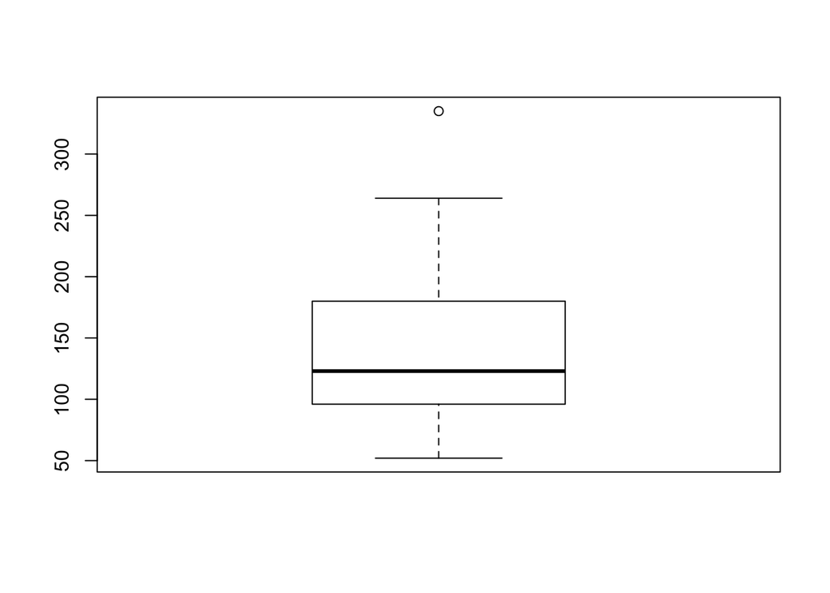

```r
boxplot(mtcars$hp)
```

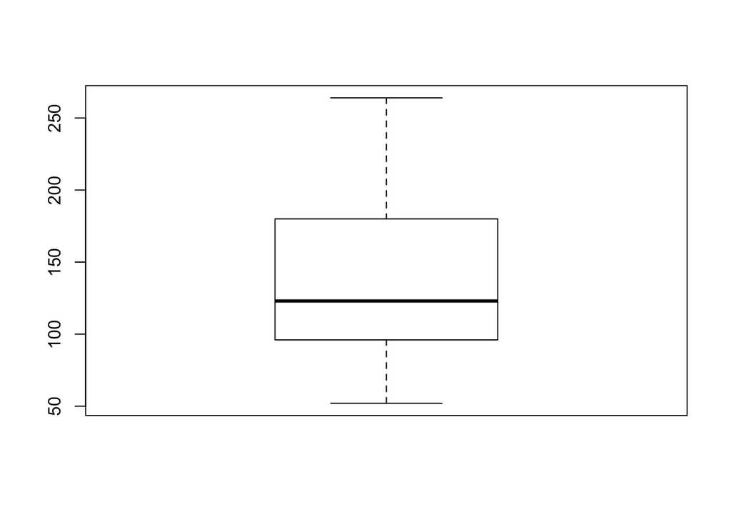

```r
# outliers are automatically labeled as dots.
# but you can exclude them if you want (notice that the y axis also automatically changes):
boxplot(mtcars$hp, outline = F)
```

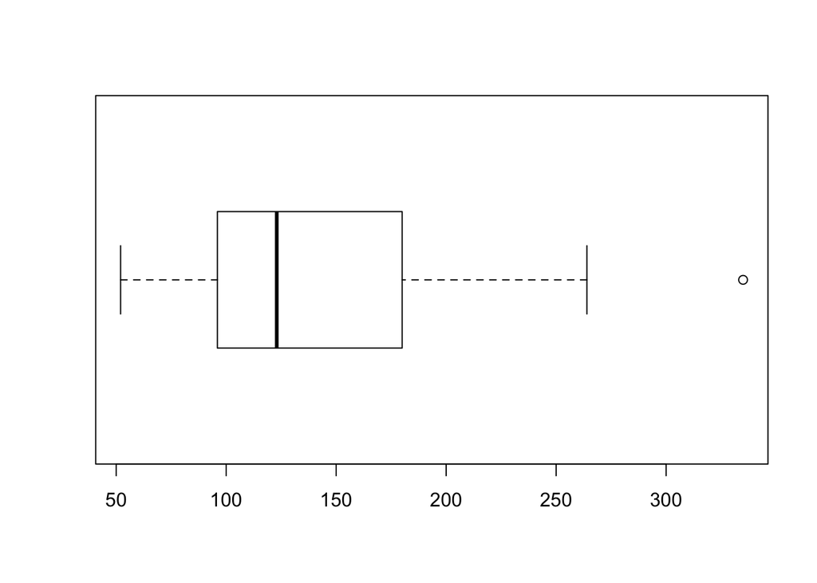

```r
# what if you prefer horizonal plots?
boxplot(mtcars$hp, horizontal = TRUE)
```

We can also use grouping variables in boxplots.

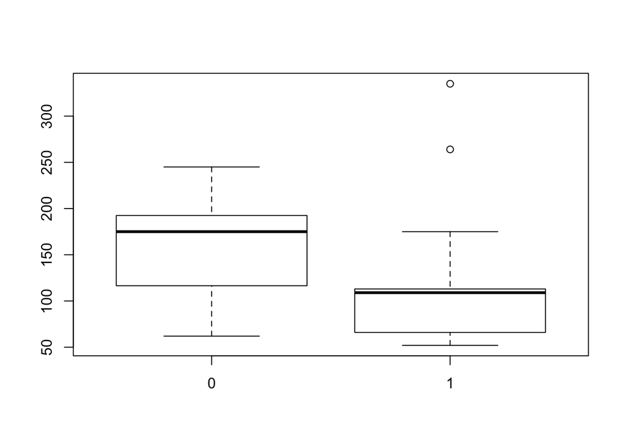

```r
# hp = y variable, am (Transmission) is our grouping (x) variable
boxplot(hp ~ am, data = mtcars)
```

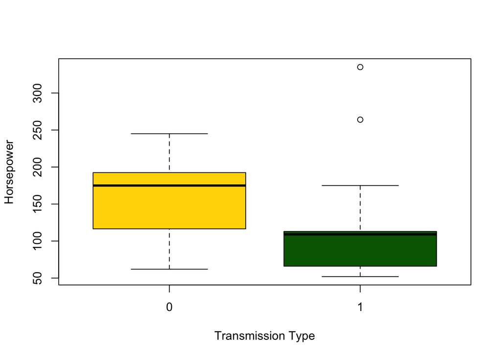

```r
# let's make this one prettier by adding axis labels and colors
boxplot(hp~ am,data=mtcars,
    xlab="Transmission Type", ylab="Horsepower", col = c("gold", "darkgreen"))
```

# 3. Basic Descriptives

Frst let’s learn how to get range, mean, sd, minimum, maximum, etc.

```r
# if you only care about the range
range(mtcars$mpg)
```

```
## [1] 10.4 33.9
```

```r
# if you only want the mean
mean(mtcars$mpg)
```

```
## [1] 20.09062
```

```r
# if you only want the sd
sd(mtcars$mpg)
```

```
## [1] 6.026948
```

```r
# the simplest way to get descriptives on a variable
summary(mtcars$mpg)
```

```
##    Min. 1st Qu.  Median    Mean 3rd Qu.    Max.
##   10.40   15.43   19.20   20.09   22.80   33.90
```

```r
# we can also combine them into a table, using the summarise function
summarise(mtcars, mean=mean(mpg), sd = sd(mpg),  min=min(mpg), max=max(mpg))
```

```
##       mean       sd  min  max
## 1 20.09062 6.026948 10.4 33.9
```

Quantiles

```r
# quantiles, if you prefer those:
quantile(mtcars$mpg)
```

```
##     0%    25%    50%    75%   100%
## 10.400 15.425 19.200 22.800 33.900
```

```r
# if you only want to extract a specific quartile:
quantile(mtcars$mpg, (0.25))
```

```
##    25%
## 15.425
```

# 4. Descriptives with grouping

We can also generate descriptive statistics based on grouping variables. Here we will on the variable mpg (miles per gallon) by 2 factors: transmission type (am) and V/S

```r
# the group_by function is from our friend, tidyverse.
# the first argument = your variable of interest
# second & third arguments are your grouping variables (factors)
grouped <- group_by(mtcars, am, vs)

# now we will extract summary statistics from the grouped data
summarise(grouped, mean=mean(mpg), sd = sd(mpg),  min=min(mpg), max=max(mpg))
```

```
## # A tibble: 4 x 6
## # Groups:   am [?]
##      am    vs     mean       sd   min   max
##   <dbl> <dbl>    <dbl>    <dbl> <dbl> <dbl>
## 1     0     0 15.05000 2.774396  10.4  19.2
## 2     0     1 20.74286 2.471071  17.8  24.4
## 3     1     0 19.75000 4.008865  15.0  26.0
## 4     1     1 28.37143 4.757701  21.4  33.9
```

# 5. Relationships between two continuous variables

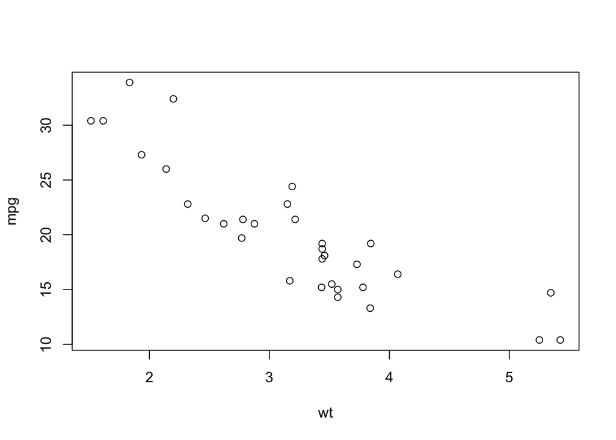

```r
plot (mpg ~ wt, data = mtcars)
```

# 6. Relationships of many variables

We can use scatterplot matrices which are a handy & quick way of visualizing relationships between multiple variables in a dataset. This works best when you have 3-5 variables (it gets too hard to read after that) - so let’s look at the first 4 variables of mtcars dataset. We can see some nice patterns here right away, mainly that cyl, disp and hp all appear to be correlated with mpg.

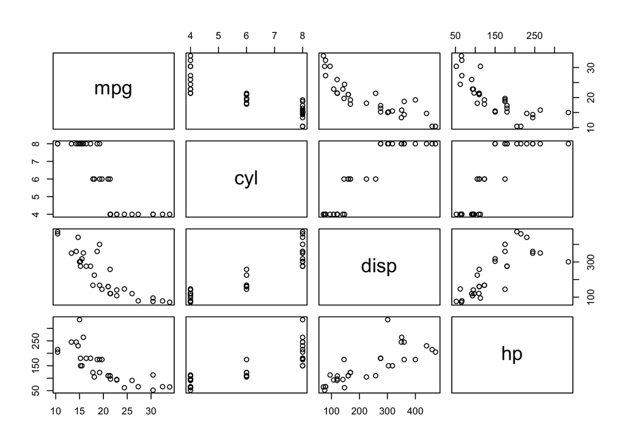

```r
#
pairs (mtcars[1:4])
```

# Data challenge:

Now it’s your turn!. This is just one subject’s data collected from the behavioral tsask.

```r
# make a histogram of the variable called "Accuracy".

# what is the skew and kurtosis of Task_Accuracy? Is it normally distributed?

# make a boxplot comparing accuracy between children and adolescents.

# what is the mean accuracy for PI children?

# Is there a linear positive or negative relationship between accuracy and age?
```